```python
import pandas as pd
import numpy as np
import matplotlib.pyplot as plt
import os
import seaborn as sns
from sklearn.preprocessing import StandardScaler
from sklearn.model_selection import train_test_split
from sklearn.ensemble import RandomForestClassifier
from sklearn.metrics import accuracy_score, precision_score, recall_score, f1_score
from sklearn.model_selection import RandomizedSearchCV
from scipy.stats import chi2_contingency
from sklearn.metrics import classification_report
from sklearn.model_selection import KFold
from sklearn.model_selection import cross_val_score
from imblearn.over_sampling import SMOTE


%matplotlib inline


os.chdir(r'D:\MyDrive2\pythonprojects\class2\DataMining\homework\ChunrAnalysis')
workdir = os.getcwd()
data_dir = os.path.join(workdir, 'data')
```

# Data Preprocessing

## Purpose: Load and examine the dataset

### Load data and drop CustomerID

```python
train = pd.read_csv(os.path.join(data_dir, 'Telco-Customer-Churn.csv'))
train.drop('customerID', axis=1, inplace=True)
train0 = train.copy()
```

```python
train
```

|  | gender | SeniorCitizen | Partner | Dependents | tenure | PhoneService | MultipleLines | InternetService | OnlineSecurity | OnlineBackup | DeviceProtection | TechSupport | StreamingTV | StreamingMovies | Contract | PaperlessBilling | PaymentMethod | MonthlyCharges | TotalCharges | Churn |
| --- | --- | --- | --- | --- | --- | --- | --- | --- | --- | --- | --- | --- | --- | --- | --- | --- | --- | --- | --- | --- |
| 0 | Female | 0 | Yes | No | 1 | No | No phone service | DSL | No | Yes | No | No | No | No | Month-to-month | Yes | Electronic check | 29.85 | 29.85 | No |
| 1 | Male | 0 | No | No | 34 | Yes | No | DSL | Yes | No | Yes | No | No | No | One year | No | Mailed check | 56.95 | 1889.5 | No |
| 2 | Male | 0 | No | No | 2 | Yes | No | DSL | Yes | Yes | No | No | No | No | Month-to-month | Yes | Mailed check | 53.85 | 108.15 | Yes |
| 3 | Male | 0 | No | No | 45 | No | No phone service | DSL | Yes | No | Yes | Yes | No | No | One year | No | Bank transfer (automatic) | 42.30 | 1840.75 | No |
| 4 | Female | 0 | No | No | 2 | Yes | No | Fiber optic | No | No | No | No | No | No | Month-to-month | Yes | Electronic check | 70.70 | 151.65 | Yes |
| ... | ... | ... | ... | ... | ... | ... | ... | ... | ... | ... | ... | ... | ... | ... | ... | ... | ... | ... | ... | ... |
| 7038 | Male | 0 | Yes | Yes | 24 | Yes | Yes | DSL | Yes | No | Yes | Yes | Yes | Yes | One year | Yes | Mailed check | 84.80 | 1990.5 | No |
| 7039 | Female | 0 | Yes | Yes | 72 | Yes | Yes | Fiber optic | No | Yes | Yes | No | Yes | Yes | One year | Yes | Credit card (automatic) | 103.20 | 7362.9 | No |
| 7040 | Female | 0 | Yes | Yes | 11 | No | No phone service | DSL | Yes | No | No | No | No | No | Month-to-month | Yes | Electronic check | 29.60 | 346.45 | No |
| 7041 | Male | 1 | Yes | No | 4 | Yes | Yes | Fiber optic | No | No | No | No | No | No | Month-to-month | Yes | Mailed check | 74.40 | 306.6 | Yes |
| 7042 | Male | 0 | No | No | 66 | Yes | No | Fiber optic | Yes | No | Yes | Yes | Yes | Yes | Two year | Yes | Bank transfer (automatic) | 105.65 | 6844.5 | No |

7043 rows × 20 columns

### If drop these 3 columns ['tenure','MonthlyCharges','TotalCharges'], 2598 lines are conflict

### Do these 3 columns have meaning?

```python
y = train['Churn']
train.drop(['Churn'], inplace=True, axis=1)
train_y = train.copy()
train_y.drop(['TotalCharges', 'MonthlyCharges', 'tenure'], inplace=True, axis=1)
dup_list = train_y.duplicated()
print(f"{dup_list.sum()} rows are duplicated if do not consider target")
train_y = train.join(y).copy()
total_dup_list = train_y.duplicated()
print(f"{total_dup_list.sum()} rows are duplicated if consider target")
conflict_list = dup_list & ~total_dup_list
print(f"{conflict_list.sum()} rows are conflict")
train_y.drop(train[conflict_list].index, inplace=True)
y = train_y['Churn']
train = train_y.drop(columns=['Churn'])

train = train0.copy()
```

```
2620 rows are duplicated if do not consider target
22 rows are duplicated if consider target
2598 rows are conflict
```

### drop conflict rows

```python
print(len(train[train.duplicated()]))
print(len(train[train.drop(['Churn'], axis=1).duplicated()]))

total_dup_list = train.duplicated()
feat_dup_list = train.drop(['Churn'], axis=1).duplicated()

conflict_list = feat_dup_list & ~total_dup_list
conflict_list.sum()
```

```
22
40
```

```
np.int64(18)
```

```python
len(train[conflict_list].index)
```

```
18
```

```python
train.drop(train[conflict_list].index, inplace=True)
```

```python
train
```

|  | gender | SeniorCitizen | Partner | Dependents | tenure | PhoneService | MultipleLines | InternetService | OnlineSecurity | OnlineBackup | DeviceProtection | TechSupport | StreamingTV | StreamingMovies | Contract | PaperlessBilling | PaymentMethod | MonthlyCharges | TotalCharges | Churn |
| --- | --- | --- | --- | --- | --- | --- | --- | --- | --- | --- | --- | --- | --- | --- | --- | --- | --- | --- | --- | --- |
| 0 | Female | 0 | Yes | No | 1 | No | No phone service | DSL | No | Yes | No | No | No | No | Month-to-month | Yes | Electronic check | 29.85 | 29.85 | No |
| 1 | Male | 0 | No | No | 34 | Yes | No | DSL | Yes | No | Yes | No | No | No | One year | No | Mailed check | 56.95 | 1889.5 | No |
| 2 | Male | 0 | No | No | 2 | Yes | No | DSL | Yes | Yes | No | No | No | No | Month-to-month | Yes | Mailed check | 53.85 | 108.15 | Yes |
| 3 | Male | 0 | No | No | 45 | No | No phone service | DSL | Yes | No | Yes | Yes | No | No | One year | No | Bank transfer (automatic) | 42.30 | 1840.75 | No |
| 4 | Female | 0 | No | No | 2 | Yes | No | Fiber optic | No | No | No | No | No | No | Month-to-month | Yes | Electronic check | 70.70 | 151.65 | Yes |
| ... | ... | ... | ... | ... | ... | ... | ... | ... | ... | ... | ... | ... | ... | ... | ... | ... | ... | ... | ... | ... |
| 7038 | Male | 0 | Yes | Yes | 24 | Yes | Yes | DSL | Yes | No | Yes | Yes | Yes | Yes | One year | Yes | Mailed check | 84.80 | 1990.5 | No |
| 7039 | Female | 0 | Yes | Yes | 72 | Yes | Yes | Fiber optic | No | Yes | Yes | No | Yes | Yes | One year | Yes | Credit card (automatic) | 103.20 | 7362.9 | No |
| 7040 | Female | 0 | Yes | Yes | 11 | No | No phone service | DSL | Yes | No | No | No | No | No | Month-to-month | Yes | Electronic check | 29.60 | 346.45 | No |
| 7041 | Male | 1 | Yes | No | 4 | Yes | Yes | Fiber optic | No | No | No | No | No | No | Month-to-month | Yes | Mailed check | 74.40 | 306.6 | Yes |
| 7042 | Male | 0 | No | No | 66 | Yes | No | Fiber optic | Yes | No | Yes | Yes | Yes | Yes | Two year | Yes | Bank transfer (automatic) | 105.65 | 6844.5 | No |

7025 rows × 20 columns

### Examine some 3-4 values variables

```python
train['Contract'].value_counts()
```

```
Contract
Month-to-month    3857
Two year          1695
One year          1473
Name: count, dtype: int64
```

```python
train['PaymentMethod'].value_counts()
```

```
PaymentMethod
Electronic check             2363
Mailed check                 1596
Bank transfer (automatic)    1544
Credit card (automatic)      1522
Name: count, dtype: int64
```

## Purpose- Handle possible missing values and incorrect data types

### Overview the features value count

```python
train.nunique()
```

```
gender                 2
SeniorCitizen          2
Partner                2
Dependents             2
tenure                73
PhoneService           2
MultipleLines          3
InternetService        3
OnlineSecurity         3
OnlineBackup           3
DeviceProtection       3
TechSupport            3
StreamingTV            3
StreamingMovies        3
Contract               3
PaperlessBilling       2
PaymentMethod          4
MonthlyCharges      1585
TotalCharges        6531
Churn                  2
dtype: int64
```

```python
train.describe()
```

|  | SeniorCitizen | tenure | MonthlyCharges |
| --- | --- | --- | --- |
| count | 7025.000000 | 7025.000000 | 7025.000000 |
| mean | 0.162562 | 32.451530 | 64.851082 |
| std | 0.368992 | 24.539465 | 30.061207 |
| min | 0.000000 | 0.000000 | 18.250000 |
| 25% | 0.000000 | 9.000000 | 35.750000 |
| 50% | 0.000000 | 29.000000 | 70.400000 |
| 75% | 0.000000 | 55.000000 | 89.900000 |
| max | 1.000000 | 72.000000 | 118.750000 |

### Check null fields existence

```python
train.isnull().sum().sum()
```

```
np.int64(0)
```

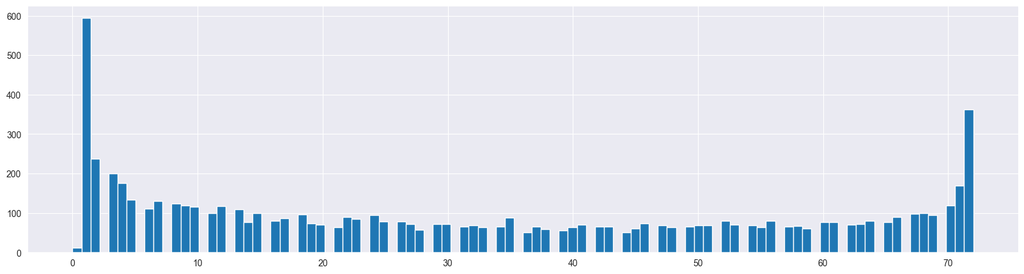

```python
plt.figure(figsize=(20, 5))
plt.hist(train['tenure'], bins=100);
```

```python
train['tenure'].value_counts().sort_index()
```

```
tenure
0      11
1     595
2     238
3     200
4     176
     ...
68    100
69     95
70    119
71    170
72    362
Name: count, Length: 73, dtype: int64
```

### A telecom customer tenure can be zero, meaning a customer has just signed up and has not yet had any service time with the company; essentially representing a brand new customer with a fresh account.

```
<BarContainer object of 2 artists>
```

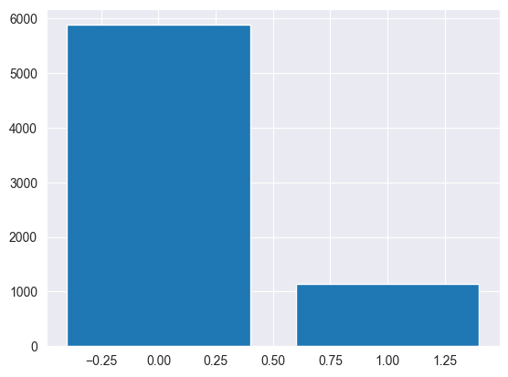

```python
plt.bar(train['SeniorCitizen'].value_counts().index, train['SeniorCitizen'].value_counts())
```

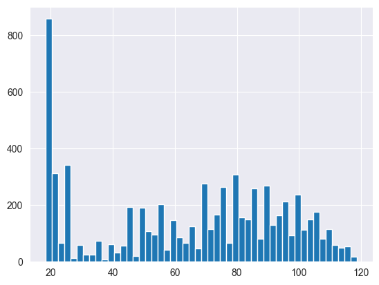

```python
plt.hist(train['MonthlyCharges'], bins=50);
```

### Drop 11 rows with TotalCharges is Na

```python
train['TotalCharges_as_float'] = pd.to_numeric(train['TotalCharges'], errors='coerce')
non_float_entries = train[train['TotalCharges_as_float'].isna()]['TotalCharges']
non_float_entries
```

```
488
753
936
1082
1340
3331
3826
4380
5218
6670
6754
Name: TotalCharges, dtype: object
```

```python
train.dropna(inplace=True)
train.drop('TotalCharges_as_float', axis=1, inplace=True)
```

```python
train['TotalCharges'] = train['TotalCharges'].astype(float)
```

Action: 11 rows are removed. Reason:column TotalCharges is NA

### Action: The column TotalCharges is converted to float.

## Transform categorical variables appropriately

```python
for f in train.columns:
    print(f, '\t\t', train[f].dtype, '\t\t', train[f].nunique(), '\t', end="")
    if train[f].unique().size <= 4:
        print(f"{train[f].unique()}")
    else:
        print(f"[]")
```

```
gender 		 object 		 2 	['Female' 'Male']
SeniorCitizen 		 int64 		 2 	[0 1]
Partner 		 object 		 2 	['Yes' 'No']
Dependents 		 object 		 2 	['No' 'Yes']
tenure 		 int64 		 72 	[]
PhoneService 		 object 		 2 	['No' 'Yes']
MultipleLines 		 object 		 3 	['No phone service' 'No' 'Yes']
InternetService 		 object 		 3 	['DSL' 'Fiber optic' 'No']
OnlineSecurity 		 object 		 3 	['No' 'Yes' 'No internet service']
OnlineBackup 		 object 		 3 	['Yes' 'No' 'No internet service']
DeviceProtection 		 object 		 3 	['No' 'Yes' 'No internet service']
TechSupport 		 object 		 3 	['No' 'Yes' 'No internet service']
StreamingTV 		 object 		 3 	['No' 'Yes' 'No internet service']
StreamingMovies 		 object 		 3 	['No' 'Yes' 'No internet service']
Contract 		 object 		 3 	['Month-to-month' 'One year' 'Two year']
PaperlessBilling 		 object 		 2 	['Yes' 'No']
PaymentMethod 		 object 		 4 	['Electronic check' 'Mailed check' 'Bank transfer (automatic)'
 'Credit card (automatic)']
MonthlyCharges 		 float64 		 1584 	[]
TotalCharges 		 float64 		 6530 	[]
Churn 		 object 		 2 	['No' 'Yes']
```

### Convert SeniorCitizen to object and 1/0

```python
#Convert SeniorCitizen to categorical
train['SeniorCitizen'] = train['SeniorCitizen'].astype('O')
train['SeniorCitizen'] = train['SeniorCitizen'].apply(lambda x: 'Yes' if x == 1 else 'No')
```

# Explore relation with tenure

add a feature--Month

```python
train['month'] = train['tenure'] % 12
train['month'] = train['month'].apply(lambda x: 12 if x == 0 else x)
train['month'] = train['month'].astype('category')
```

## TotalCharge and MonthlyCharge

[output not shown]

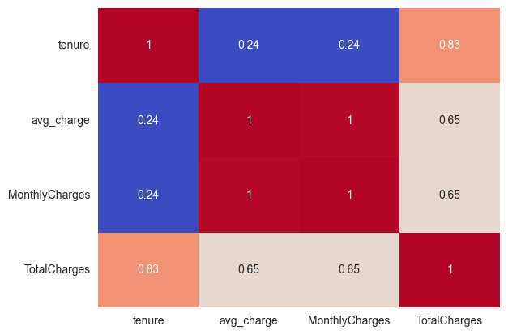

```python
train['avg_charge'] = train['TotalCharges'] / train['tenure']
df = train[['tenure', 'avg_charge', 'MonthlyCharges', 'TotalCharges']]
sns.heatmap(df.corr(), annot=True, cmap='coolwarm', cbar=False)
plt.yticks(rotation=0)
```

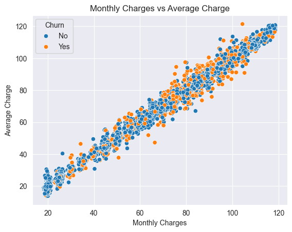

```python
# plt.scatter(x='MonthlyCharges', y='avg_charge', data=df)
df['Churn'] = train['Churn']
sns.scatterplot(x='MonthlyCharges', y='avg_charge', data=df, hue='Churn')
plt.xlabel('Monthly Charges')
plt.ylabel('Average Charge')
plt.title('Monthly Charges vs Average Charge')
```

### Encode Churn into 1/0

```python
train['Churn'] = train['Churn'].apply(lambda x: 1 if x == 'Yes' else 0)
train['Churn'] = train['Churn'].astype('int')
```

### The monthly charges correlate to total charges devided by tenure but not the same

I tend to recognize the Monthlycharges column is the last month's charges, the last attitude before customer churn.

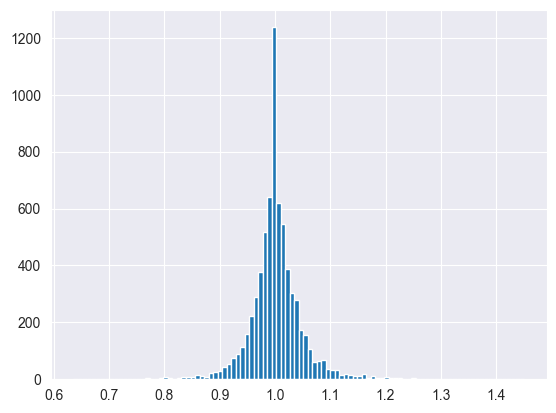

```python
train['mc_vs_avg'] = train['MonthlyCharges'] / train['avg_charge']
plt.hist(train['mc_vs_avg'], bins=100)
```

### The mc_vs_avg give the ratio that the last month's charge vs total mean month charge

```python
train.columns
```

```
Index(['gender', 'SeniorCitizen', 'Partner', 'Dependents', 'tenure',
       'PhoneService', 'MultipleLines', 'InternetService', 'OnlineSecurity',
       'OnlineBackup', 'DeviceProtection', 'TechSupport', 'StreamingTV',
       'StreamingMovies', 'Contract', 'PaperlessBilling', 'PaymentMethod',
       'MonthlyCharges', 'TotalCharges', 'Churn', 'month', 'avg_charge',
       'mc_vs_avg'],
      dtype='object')
```

### Target Encoding

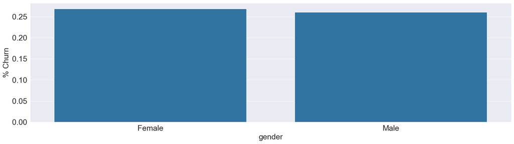

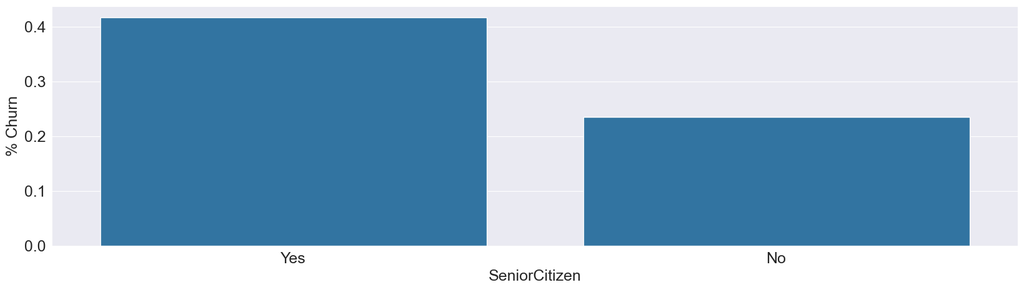

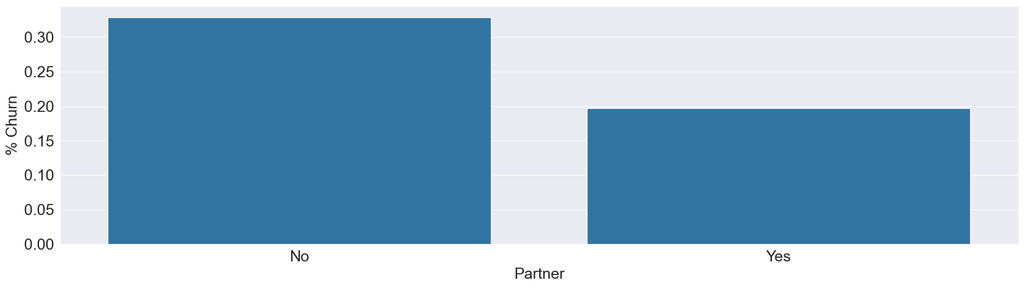

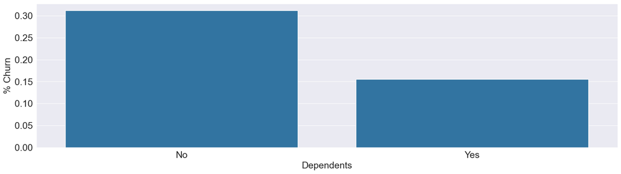

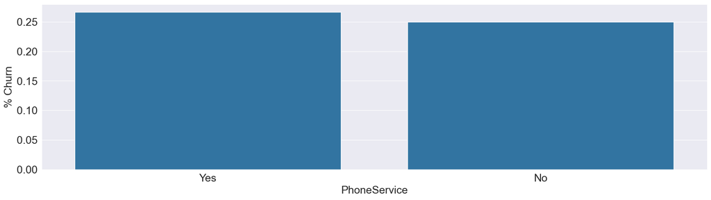

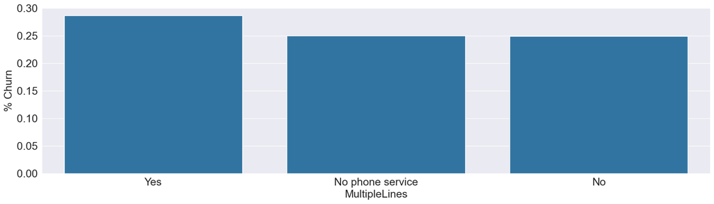

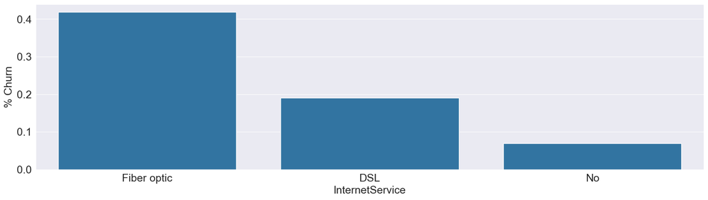

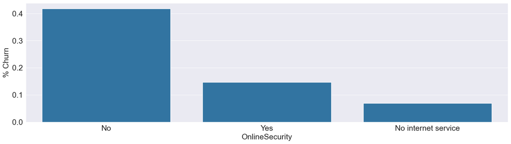

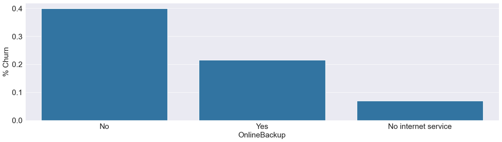

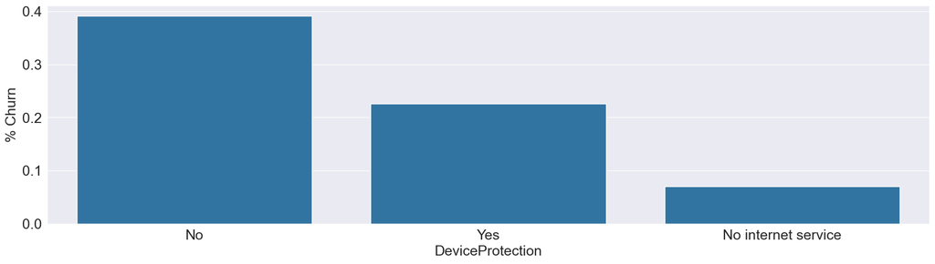

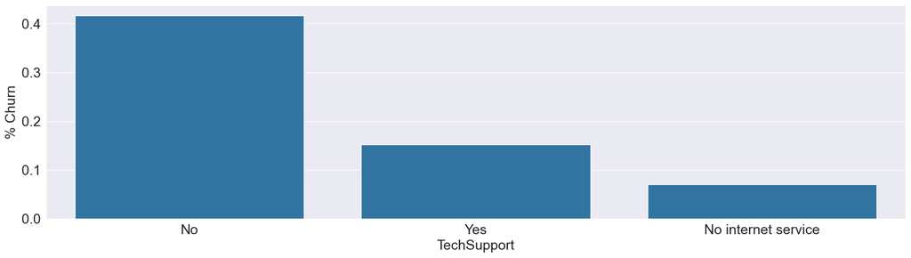

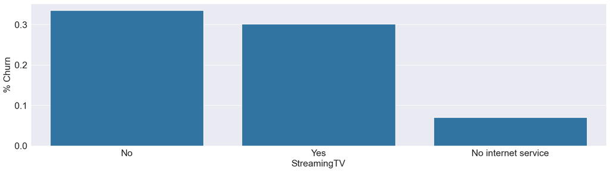

[5 more figures not shown]

```python
for f in train.columns:
    if train[f].nunique() > 12:
        continue
    if f == 'Churn':
        continue
    plt.figure()
    fig, ax = plt.subplots(figsize=(20, 5))
    # Calculate the percentage of target=1 per category value

    cat_perc = train[[f, 'Churn']].groupby([f], as_index=False).mean()
    cat_perc.sort_values(by='Churn', ascending=False, inplace=True)
    # Bar plot
    # Order the bars descending on target mean
    sns.barplot(ax=ax, x=f, y='Churn', data=cat_perc, order=cat_perc[f])
    plt.ylabel('% Churn', fontsize=18)
    plt.xlabel(f, fontsize=18)
    plt.tick_params(axis='both', which='major', labelsize=18)
    plt.show()
```

### Check target imbalance.

The balance is not bad. Churn:Existing = 0.36

```python
train['Churn'].value_counts()
```

```
Churn
0    5155
1    1859
Name: count, dtype: int64
```

Should You Use One-Hot Encoding for Binary Variables? Whether to use one-hot encoding depends on the machine learning algorithm you're working with:

1. **When NOT to Use One-Hot Encoding (Binary Encoding is Enough)**:
- **Tree-Based Models**: Algorithms like Decision Trees, Random Forests, and Gradient Boosted Trees (e.g., XGBoost, LightGBM) *do not require* one-hot encoding. These models handle numerical and categorical features well, and binary encoding provides the same information as one-hot encoding.
- **Dimensionality Reduction**: One-hot encoding increases the dataset's dimensionality. For binary features, one-hot encoding is redundant because it adds an extra column that carries no additional information (the second column is the inverse of the first).
2. **When to Consider One-Hot Encoding**:
- **When Using Linear Models**: Algorithms like Logistic Regression and Linear Regression might benefit from one-hot encoding, depending on how the data is structured. These models assume linear relationships, and one-hot encoding can prevent issues where a single numeric column (e.g., 0 or 1) might suggest an ordinal relationship.
- **For Consistency**: If you are consistently one-hot encoding categorical features and want to treat all of them uniformly, you might also encode binary variables using one-hot.

Key Takeaways:

1. **Binary Encoding (0/1) works well for binary variables**, especially with tree-based models, as they can handle categorical features directly.
2. **One-Hot Encoding is generally unnecessary for binary features** but can be used with linear models or when consistency across all categorical features is desired.
3. **Efficiency Matters**: Skipping one-hot encoding for binary variables reduces the dimensionality of your dataset and simplifies data preparation.

### Action- Drop customerID ;drop Churn to y as target

## Create normalized versions of relavant variables

### interval columns analysis

```python
numeric_columns = []
for f in train.columns:
    if train[f].nunique() > 12:
        numeric_columns.append(f)
numeric_columns
```

```
['tenure', 'MonthlyCharges', 'TotalCharges', 'avg_charge', 'mc_vs_avg']
```

```python
train[numeric_columns]
```

|  | tenure | MonthlyCharges | TotalCharges | avg_charge | mc_vs_avg |
| --- | --- | --- | --- | --- | --- |
| 0 | 1 | 29.85 | 29.85 | 29.850000 | 1.000000 |
| 1 | 34 | 56.95 | 1889.50 | 55.573529 | 1.024768 |
| 2 | 2 | 53.85 | 108.15 | 54.075000 | 0.995839 |
| 3 | 45 | 42.30 | 1840.75 | 40.905556 | 1.034089 |
| 4 | 2 | 70.70 | 151.65 | 75.825000 | 0.932410 |
| ... | ... | ... | ... | ... | ... |
| 7038 | 24 | 84.80 | 1990.50 | 82.937500 | 1.022457 |
| 7039 | 72 | 103.20 | 7362.90 | 102.262500 | 1.009168 |
| 7040 | 11 | 29.60 | 346.45 | 31.495455 | 0.939818 |
| 7041 | 4 | 74.40 | 306.60 | 76.650000 | 0.970646 |
| 7042 | 66 | 105.65 | 6844.50 | 103.704545 | 1.018760 |

7014 rows × 5 columns

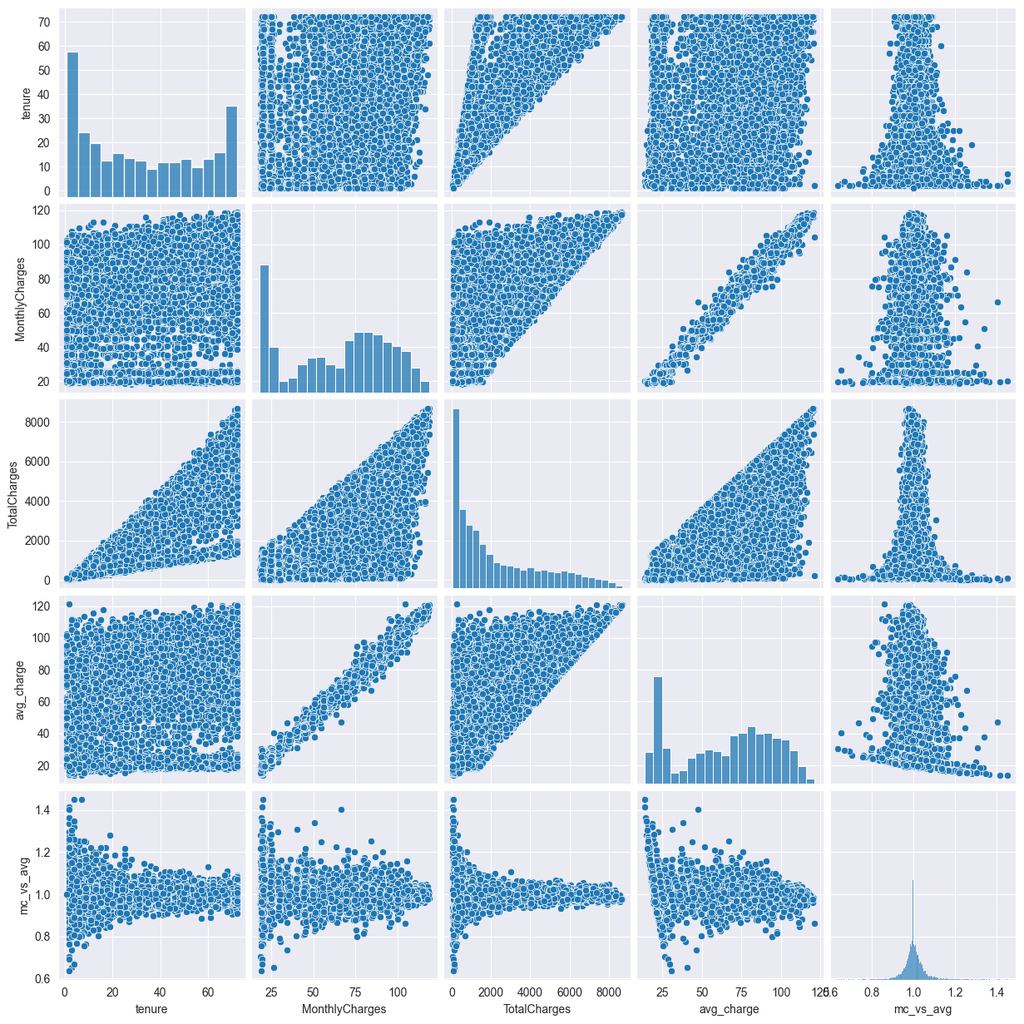

```python
sns.pairplot(train[numeric_columns])
```

```python
numeric_columns
```

```
['tenure', 'MonthlyCharges', 'TotalCharges', 'avg_charge', 'mc_vs_avg']
```

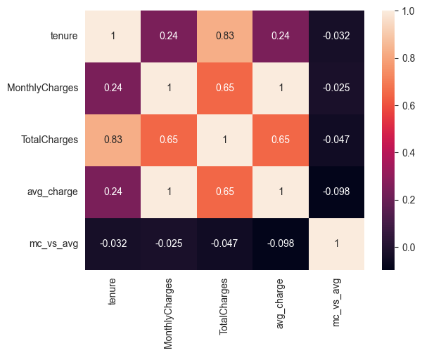

```python
sns.heatmap(train[numeric_columns].corr(), annot=True)
```

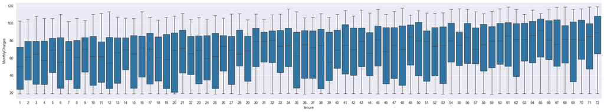

```python
plt.figure(figsize=(30, 5))
sns.boxplot(x=train['tenure'], y=train['MonthlyCharges'])
```

### Conclusion: Monthly Charges does not change too much. I guess it mainly related to inflation.

```python
train.describe()
```

|  | tenure | MonthlyCharges | TotalCharges | Churn | avg_charge | mc_vs_avg |
| --- | --- | --- | --- | --- | --- | --- |
| count | 7014.000000 | 7014.000000 | 7014.000000 | 7014.000000 | 7014.000000 | 7014.000000 |
| mean | 32.502424 | 64.887831 | 2289.083397 | 0.265041 | 64.889050 | 1.002317 |
| std | 24.524997 | 30.056965 | 2266.797933 | 0.441387 | 30.157231 | 0.051354 |
| min | 1.000000 | 18.250000 | 18.800000 | 0.000000 | 13.775000 | 0.635545 |
| 25% | 9.000000 | 35.750000 | 406.275000 | 0.000000 | 36.505357 | 0.980691 |
| 50% | 29.000000 | 70.400000 | 1401.825000 | 0.000000 | 70.453125 | 1.000000 |
| 75% | 56.000000 | 89.900000 | 3806.612500 | 1.000000 | 90.227604 | 1.020930 |
| max | 72.000000 | 118.750000 | 8684.800000 | 1.000000 | 121.400000 | 1.450628 |

### normalize the numeric_columns

```python
scaler = StandardScaler()
df_std = train[numeric_columns].copy()
df_std[numeric_columns] = scaler.fit_transform(df_std)
```

```python
train['Churn']
```

```
0       0
1       0
2       1
3       0
4       1
       ..
7038    0
7039    0
7040    0
7041    1
7042    0
Name: Churn, Length: 7014, dtype: int64
```

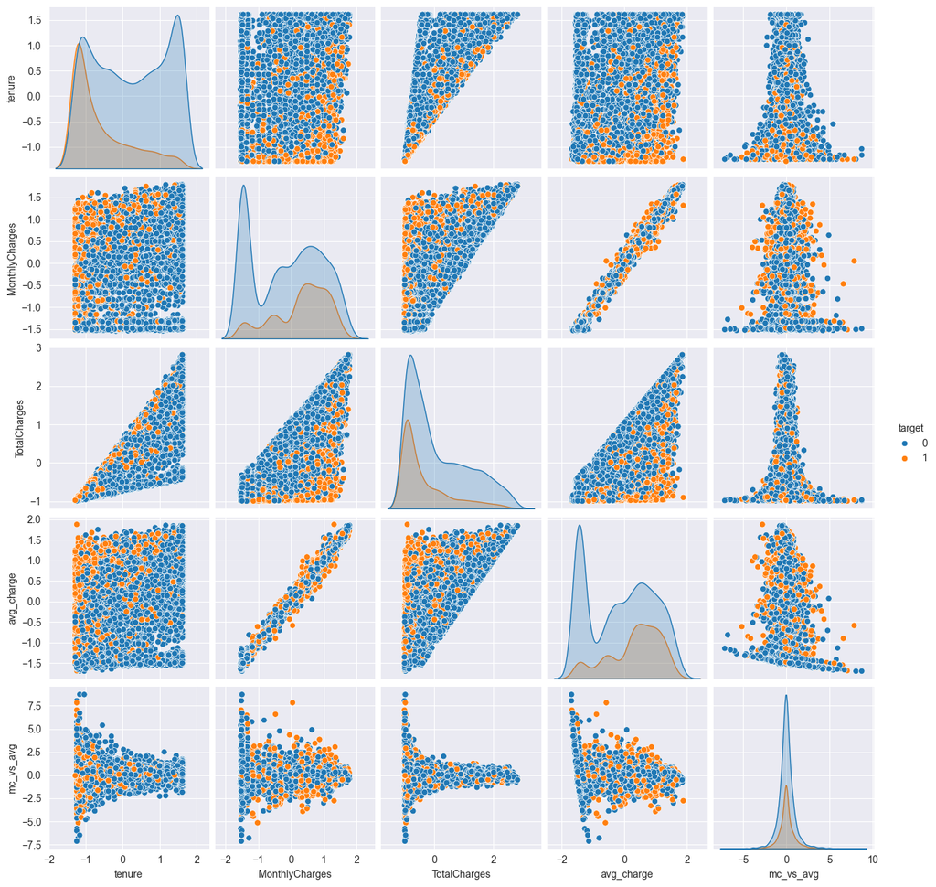

```python
df_std['target'] = train['Churn'].astype('O')
df = df_std
sns.pairplot(df, hue='target')
```

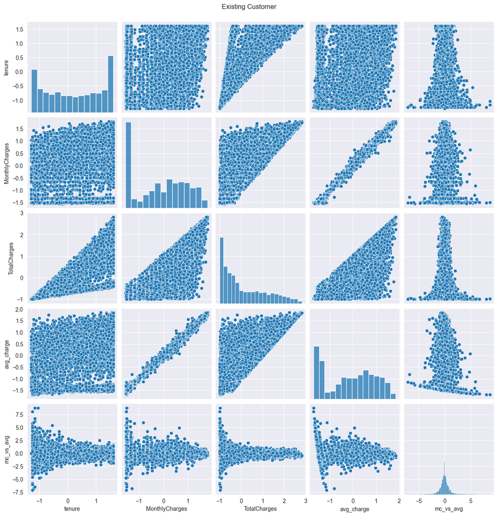

```python
df = df_std[df_std['target'] == 0].copy()
df.drop('target', axis=1, inplace=True)
pairplot = sns.pairplot(df)
pairplot.fig.suptitle('Existing Customer', y=1.02)
```

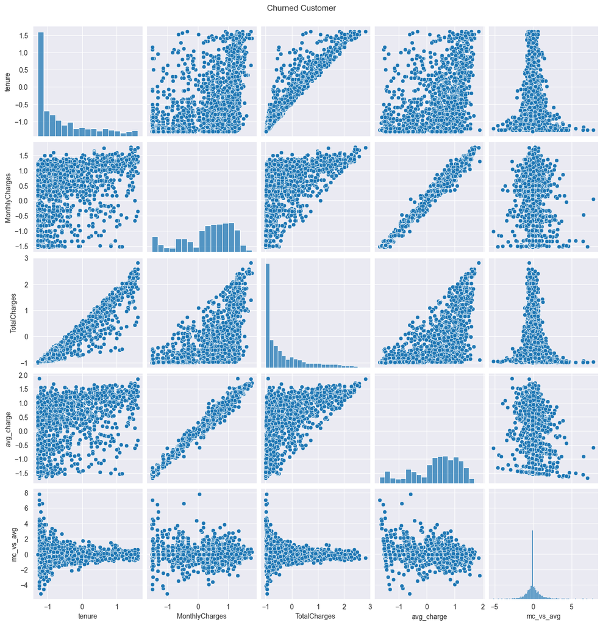

```python
df = df_std[df_std['target'] == 1].copy()
df.drop('target', axis=1, inplace=True)
pairplot = sns.pairplot(df)
pairplot.fig.suptitle('Churned Customer', y=1.02)
```

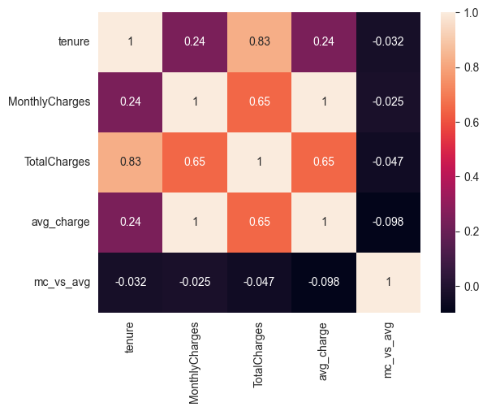

```python
sns.heatmap(train[numeric_columns].corr(), annot=True)
```

```python
scaler = StandardScaler()

train[numeric_columns] = scaler.fit_transform(train[numeric_columns])
```

### Check numeric variables correlation with target

```python
y = train['Churn']
```

```python
correlation_with_target = train[numeric_columns].join(y).corr()
correlation_with_target['Churn']
```

```
tenure           -0.353405
MonthlyCharges    0.195623
TotalCharges     -0.198494
avg_charge        0.194784
mc_vs_avg         0.011741
Churn             1.000000
Name: Churn, dtype: float64
```

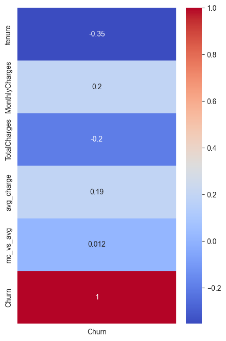

```python
plt.figure(figsize=(5, 8))
sns.heatmap(correlation_with_target[['Churn']], annot=True, cmap='coolwarm', cbar=True)
```

### Target Encoding for numeric variables

```python
train['binned_MonthlyCharges'] = pd.cut(train['MonthlyCharges'], bins=[i for i in
                                                                       np.arange(min(train['MonthlyCharges']),
                                                                                 max(train['MonthlyCharges']), (max(
                                                                               train['MonthlyCharges']) - min(
                                                                               train['MonthlyCharges'])) / 73)])
train['binned_TotalCharges'] = pd.cut(train['TotalCharges'], bins=[i for i in np.arange(min(train['TotalCharges']),
                                                                                        max(train['TotalCharges']),
                                                                                        (max(train['TotalCharges']) -
                                                                                         min(train[
                                                                                                 'TotalCharges'])) / 73)])

train['binned_mc_vs_avg'] = pd.cut(train['mc_vs_avg'], bins=[i for i in np.arange(min(train['mc_vs_avg']),
                                                                                  max(train['mc_vs_avg']),
                                                                                  (max(train['mc_vs_avg']) -
                                                                                   min(train['mc_vs_avg'])) / 73)])
train = train.dropna(subset=['binned_mc_vs_avg'])

train['binned_avg_charge'] = pd.cut(train['avg_charge'], bins=[i for i in np.arange(min(train['avg_charge']),
                                                                                    max(train['avg_charge']),
                                                                                    (max(train['avg_charge']) -
                                                                                     min(train['avg_charge'])) / 73)])
```

```python
train['binned_MonthlyCharges'].describe()
```

```
count                7000
unique                 72
top       (-1.506, -1.46]
freq                  829
Name: binned_MonthlyCharges, dtype: object
```

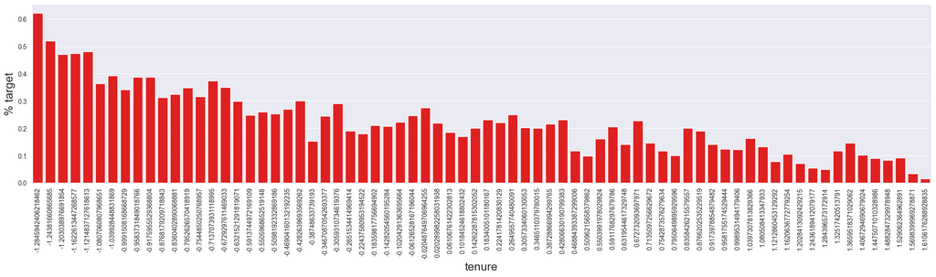

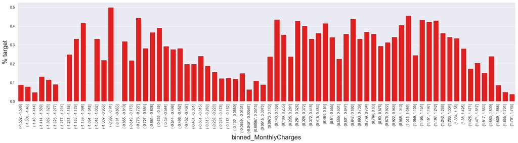

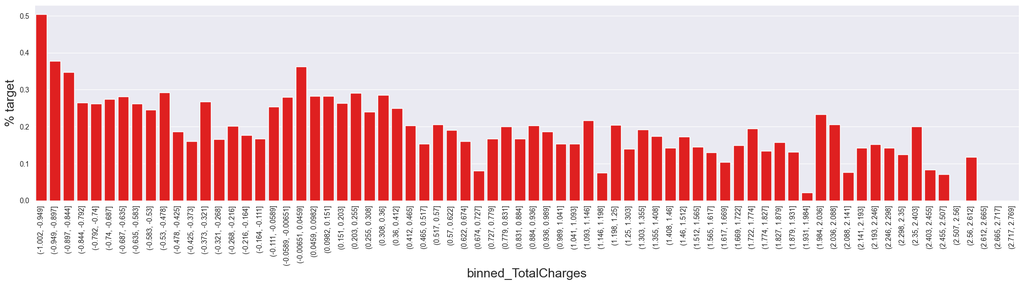

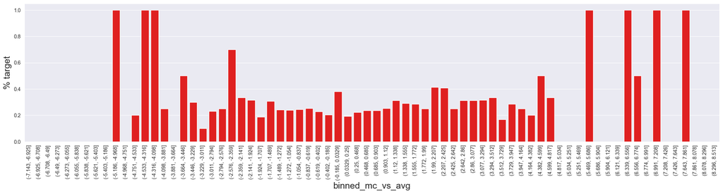

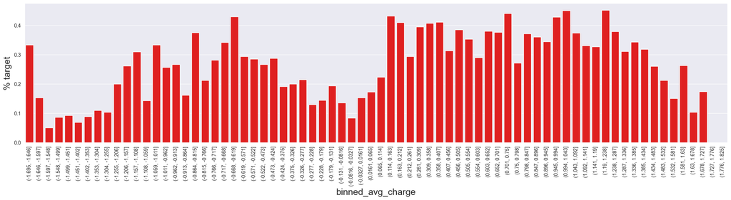

```python
from matplotlib.ticker import MaxNLocator

# from pandas.api.types import is_interval_dtype

interval_columns_bin = ['tenure', 'binned_MonthlyCharges', 'binned_TotalCharges', 'binned_mc_vs_avg',
                        'binned_avg_charge']
for f in interval_columns_bin:
    data = train[[f]].join(y)
    plt.figure()
    fig, ax = plt.subplots(figsize=(25, 5))

    # Calculate the percentage of target=1 per category value
    cat_perc = data[[f, 'Churn']].groupby([f], as_index=False).mean()
    cat_perc.sort_values(by=f, ascending=True, inplace=True)

    sns.barplot(ax=ax, x=f, y='Churn', data=cat_perc, order=cat_perc[f], color='red')
    # plt.xticks(rotation=90, ticks=[i for i in np.arange(min(train[f]),max(train[f]))])
    # plt.xticks(rotation=90, labels=[i for i in range(0, train['tenure'].nunique())],
    #            ticks=[i for i in range(0, train['tenure'].nunique())])
    plt.ylabel('% target', fontsize=18)
    plt.xlabel(f, fontsize=18)
    plt.xticks(rotation=90)
    # ax.xaxis.set_major_locator(MaxNLocator(integer=True, nbins=73))
    # plt.ylim(0, 0.1)
    plt.show()
```